# DeepTrack data

Junyao Jiang

2026-04-09

This page offers descriptions and download links for all well-processed sequencing data from the DeepTrack paper.

# Download link

https://westlakeu-my.sharepoint.com/:f:/g/personal/jiangjunyao_westlake_edu_cn/IgDnwChsoIUwTJYOXuZrEGByAZ7zONhr2hZVZiz2zdeaKkY

# Data descriptions

## High-resolution figures for DeepTrack manuscript

**Main figures.pdf**: High-resolution main figures (Figure 1-6) for DeepTrack manuscript

**Supplymental figures.pdf**: High-resolution supplymental figures(Figure S1-S10) for DeepTrack manuscript

## Experiment 1: Bulk lineage tracing (Figure1)

**Bulk lineage tracing.csv**: This is bulk lineage tracing data from two E18.5 mouse embryos. Each row represents a single clone, and each column represents a single tissue.

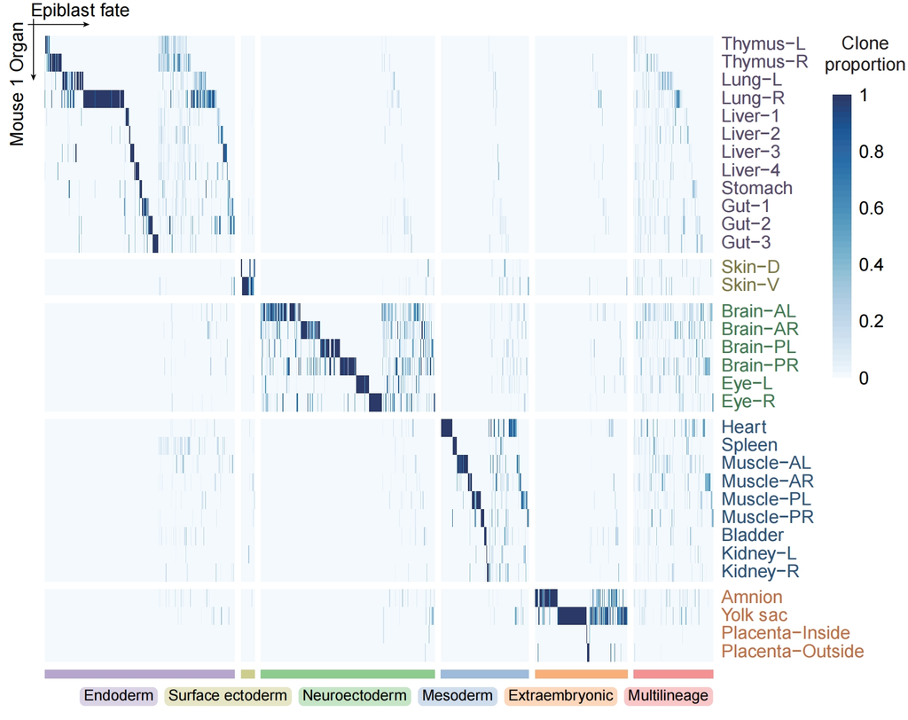

## Experiment 2: Single cell lineage tracing (Figure2-3)

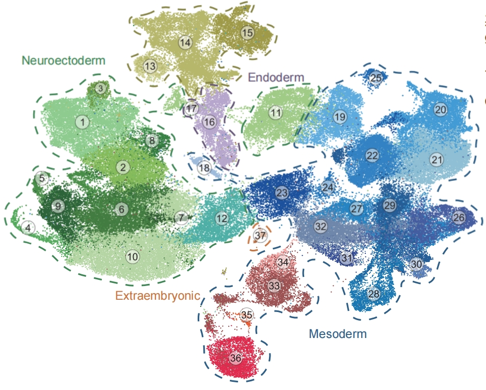

## Experiment 3: Single cell multiomics lineage tracing (Figure4-5)

**single cell multiomics lineage tracing.rds**: This is a well-processed Seurat object that encompasses all multiomics single-cell lineage tracing data featured in Figure 4. The dataset contains 87,166 (60,355 whole embryo cells and 26,811 trunk tissue cells) cells with multi-modality from three E9.5 mouse embryos. The ‘barcodes’ column in the obs attribute represents cell-specific lineage barcodes.

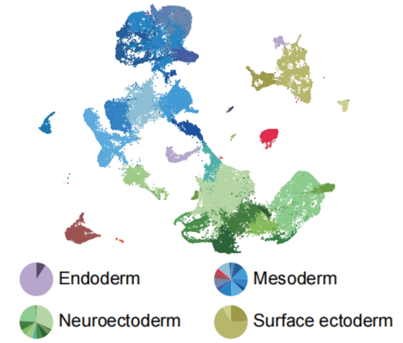

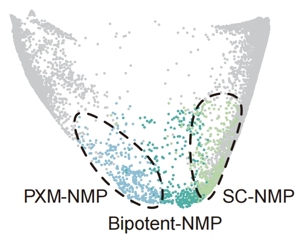

## Experiment 4: scRNA-seq for Cdx2-mutant embryos (Figure6)

**Cdx2 KO.h5ad**: This is a well-processed AnnData object for scRNA-seq data from E10.5 Cdx2-mutant chimeras, including 11,098 Cdx2-mutant cells and 13,901 wild-type cells.

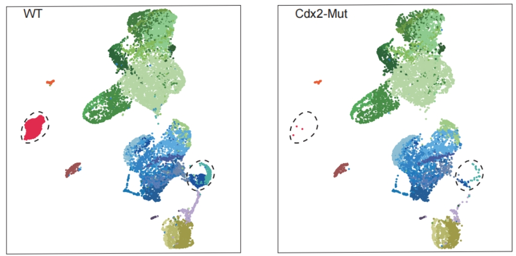